```python
import pandas as pd
import numpy as np
import matplotlib.pyplot as plt
import seaborn as sns
import plotly.express as px
```

# Задание 1

## Сгенерируйте 200 IID*, случайных переменных, полученных из распределения Пуассона с lambda = 6.

IID (independent and identically distributed) - независимые одинаково распределенные случайные переменные.

```python
poisson_200 = np.random.poisson(lam=6.0,size=200)
```

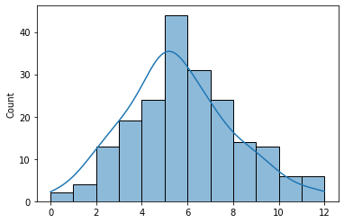

```python
sns.histplot(poisson_200, kde=True)
```

## Проведите такую симуляцию 2 000 раз и в каждой итерации вычислите среднее значение этих 200 случайных переменных.

```python
lambda_ = 6
poisson_array = np.random.poisson(lam=lambda_, size=(2000, 200))
```

```python
poisson_array_means = np.mean(poisson_array, axis=1)
```

## На основе полученной выборки постройте гистограмму из 2 000 средних.

```python
poisson_array_means
```

```
array([6.245, 6.04 , 6.015, ..., 6.18 , 6.205, 5.985])
```

```python
poisson_array_means.shape
```

```
(2000,)
```

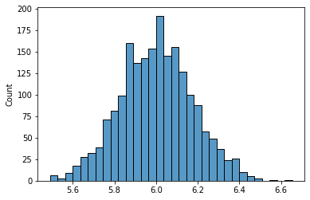

```python
sns.histplot(poisson_array_means)
```

## Ответьте на такие вопросы:

### Какими свойствами обладает такое распределение?

Исходя из центральной предельной теоремы, распределение, составленное из выборочных средних другого распределения, будет иметь нормальный вид при достаточно большой выборке (n>30). А значит - наше распределение выборочных средних будет как раз иметь свойства нормального распределения

### Что можно утверждать о стандартном отклонении, среднем значении и дисперсии полученной выборки средних?

**Стандартное отклонение выборки средних** - (se, стандартная ошибка среднего) должно быть приблизительно равно:

$$ se = \frac {\sigma} {\sqrt{n}} {\text{, где}}$$

$$ {\text{n - размер выборки, }} \sigma {\text{ - стандартное отклонение генеральной совокупности}}$$

Если посчитаем напрямую из выборки, то получим значение se, равное

```python
round(poisson_array_means.std(), 3)
```

```
0.174
```

Также знаем, что в распределении Пуассона: $$ \sigma = {\sqrt{\lambda}} $$

Потому зная параметр лямбда и размер выборки распределения средних, мы можем сразу узнать se полученной выборки

```python
se = lambda_**0.5/200**0.5
print("Рассчётное std распределения средних (se) = {:f}".\
    format(se))
```

```
Рассчётное std распределения средних (se) = 0.173205
```

**Среднее значение** выборки средних должно соответствовать среднему значению генеральной совокупности

```python
print(f"""Среднее значение выборки средних = {poisson_array_means.mean()};
Среднее значение генеральной совокупности = {poisson_array.flatten().mean()}""")
```

```
Среднее значение выборки средних = 6.00158;
Среднее значение генеральной совокупности = 6.00158
```

Также можно сказать, что с увеличением количества размера выборки уменьшится **стандартная ошибка среднего**, а значит, и **дисперсия** нашей выборки средних

### Что изменится, если использовать экспоненциальное распределение с lambda = 0.5?

Изменится как среднее значение, так и стандартная ошибка с дисперсией выборки средних. Стандартное отклонение должно по идее уменьшится из-за того, что распределение будет "упираться" в ось ординат и минимальное значение для распределение Пуассона, что можно проверить, изменив переменную **lambda_**. Само распределение выборочных средних останется нормальным

# Задание 2

На распродаже 23–26 ноября игроки получали скидку на определенный набор игровых предметов. Используя данные таблицы AnalyticalTest.csv , посчитайте показатели запуска внутриигровой скидки, а также отдельно по цене для скидки 4137 и скидки 4138:

```python
#к-во пользователей, получивших скидку
human_discount_num = 275_000
```

```python
df_ref = pd.read_csv('Analytical Test.csv', decimal=",", sep=';')
```

```python
df_ref.head(10)
```

|  | userid | day | time | revenue | offerid | promotionid | price |
| --- | --- | --- | --- | --- | --- | --- | --- |
| 0 | id83902161592 | 2021-10-17 | 2021-10-17 12:28:42.9441 UTC | 8.499019 | NaN | NaN | 9.96 |
| 1 | id152617854404 | 2021-10-17 | 2021-10-17 06:19:13.5882 UTC | 6.651215 | NaN | NaN | 15.78 |
| 2 | id83900752467 | 2021-10-17 | 2021-10-17 12:57:09.2295 UTC | 24.367235 | NaN | NaN | 20.10 |
| 3 | id83897991208 | 2021-10-17 | 2021-10-17 20:58:32.4207 UTC | 34.358858 | 3245.0 | 1074.0 | 34.99 |
| 4 | id83901723932 | 2021-10-17 | 2021-10-17 22:22:24.087 UTC | 10.772394 | NaN | NaN | 9.34 |
| 5 | id83902488594 | 2021-10-17 | 2021-10-17 21:22:48.4106 UTC | 27.204741 | 17386.0 | 1074.0 | 22.49 |
| 6 | id83902242405 | 2021-10-17 | 2021-10-17 01:58:46.6134 UTC | 48.734470 | 17390.0 | 1074.0 | 39.99 |
| 7 | id83900752467 | 2021-10-17 | 2021-10-17 12:57:23.1374 UTC | 12.183617 | NaN | NaN | 10.05 |
| 8 | id83899299583 | 2021-10-17 | 2021-10-17 19:57:05.1818 UTC | 18.894398 | NaN | NaN | 19.55 |
| 9 | id83902170090 | 2021-10-17 | 2021-10-17 22:32:50.0264 UTC | 4.105517 | NaN | NaN | 4.98 |

```python
df_ref.info()
```

```
<class 'pandas.core.frame.DataFrame'>
RangeIndex: 116423 entries, 0 to 116422
Data columns (total 7 columns):
 #   Column       Non-Null Count   Dtype
---  ------       --------------   -----
 0   userid       116423 non-null  object
 1   day          116423 non-null  object
 2   time         116423 non-null  object
 3   revenue      116423 non-null  float64
 4   offerid      89793 non-null   float64
 5   promotionid  90209 non-null   float64
 6   price        116423 non-null  float64
dtypes: float64(4), object(3)
memory usage: 6.2+ MB
```

```python
df_ref.describe()
```

|  | revenue | offerid | promotionid | price |
| --- | --- | --- | --- | --- |
| count | 116423.000000 | 89793.000000 | 9.020900e+04 | 116423.000000 |
| mean | 19.609339 | 15459.591082 | 5.923741e+04 | 21.026738 |
| std | 28.463914 | 4175.930796 | 2.626808e+05 | 27.391898 |
| min | 0.029760 | 917.000000 | -1.000000e+00 | 0.010000 |
| 25% | 4.042327 | 15298.000000 | 3.232000e+03 | 5.030000 |
| 50% | 9.642599 | 16380.000000 | 3.413000e+03 | 9.990000 |
| 75% | 19.800719 | 17861.000000 | 3.865000e+03 | 19.990000 |
| max | 491.040000 | 19208.000000 | 2.000001e+06 | 329.990000 |

```python
df_ref[df_ref['revenue'].isna()]
```

|  | userid | day | time | revenue | offerid | promotionid | price |
| --- | --- | --- | --- | --- | --- | --- | --- |

```python
df_ref[df_ref['price'].isna()]
```

|  | userid | day | time | revenue | offerid | promotionid | price |
| --- | --- | --- | --- | --- | --- | --- | --- |

Так как минимальное значение revenue и price != 0,то значит, что данная таблица отображает только информацию о внутриигровых покупках/транзакциях

Приведу даты к необходимому типу данных

```python
df_ref['day'] = pd.to_datetime(df_ref['day'])
df_ref['time'] = pd.to_datetime(df_ref['time'])

#для дальнейшего удобства заменю NaN в promotionid на  0
#избавлюсь от дробной части в номере promotionid, чтобы потом вышло нормально перевести
#весь столбец в тип данных str (понадобится для построения графиков в будущем)
df_ref['promotionid'] = df_ref['promotionid'].fillna(0)
df_ref['promotionid'] = df_ref['promotionid'].astype(int).astype(str)
```

```python
df_ref
```

|  | userid | day | time | revenue | offerid | promotionid | price |
| --- | --- | --- | --- | --- | --- | --- | --- |
| 0 | id83902161592 | 2021-10-17 | 2021-10-17 12:28:42.944100+00:00 | 8.499019 | NaN | 0 | 9.96 |
| 1 | id152617854404 | 2021-10-17 | 2021-10-17 06:19:13.588200+00:00 | 6.651215 | NaN | 0 | 15.78 |
| 2 | id83900752467 | 2021-10-17 | 2021-10-17 12:57:09.229500+00:00 | 24.367235 | NaN | 0 | 20.10 |
| 3 | id83897991208 | 2021-10-17 | 2021-10-17 20:58:32.420700+00:00 | 34.358858 | 3245.0 | 1074 | 34.99 |
| 4 | id83901723932 | 2021-10-17 | 2021-10-17 22:22:24.087000+00:00 | 10.772394 | NaN | 0 | 9.34 |
| ... | ... | ... | ... | ... | ... | ... | ... |
| 116418 | id221336248418 | 2021-10-19 | 2021-10-19 15:53:22.864600+00:00 | 8.068259 | 16803.0 | 3216 | 7.99 |
| 116419 | id83899524554 | 2021-10-19 | 2021-10-19 14:17:57.218400+00:00 | 8.068259 | 16803.0 | 3216 | 7.99 |
| 116420 | id83903173585 | 2021-10-19 | 2021-10-19 20:56:19.159900+00:00 | 7.859943 | 16803.0 | 3216 | 7.99 |
| 116421 | id83901971215 | 2021-10-19 | 2021-10-19 18:56:04.580000+00:00 | 7.584447 | 16803.0 | 3216 | 7.99 |
| 116422 | id152617988894 | 2021-10-19 | 2021-10-19 20:10:04.230800+00:00 | 2.675590 | 16803.0 | 3217 | 7.99 |

116423 rows × 7 columns

Проверю количество уникальных юзеров в таблице

```python
df_ref['userid'].nunique()
```

```
12617
```

Посмотрю диапазон дат

```python
df_ref['day'].min(), df_ref['day'].max()
```

```
(Timestamp('2020-01-01 00:00:00'), Timestamp('2021-12-31 00:00:00'))
```

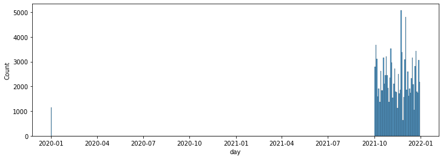

```python
plt.figure(figsize=(12,4))
sns.histplot(x=df_ref['day'])
```

```python
df_ref[df_ref['day']=='2020-01-01']
```

|  | userid | day | time | revenue | offerid | promotionid | price |
| --- | --- | --- | --- | --- | --- | --- | --- |
| 777 | id83902883474 | 2020-01-01 | 2020-01-01 16:20:43.319500+00:00 | 35.895704 | 17390.0 | 1074 | 39.99 |
| 778 | id221336509587 | 2020-01-01 | 2020-01-01 13:53:12.540300+00:00 | 22.454628 | NaN | 0 | 20.10 |
| 779 | id83901438728 | 2020-01-01 | 2020-01-01 01:06:07.401400+00:00 | 7.960323 | NaN | 0 | 9.34 |
| 780 | id83902735265 | 2020-01-01 | 2020-01-01 22:52:51.488200+00:00 | 49.501796 | NaN | 0 | 50.21 |
| 781 | id83903187689 | 2020-01-01 | 2020-01-01 20:53:18.500100+00:00 | 16.293600 | 3231.0 | 1074 | 10.99 |
| ... | ... | ... | ... | ... | ... | ... | ... |
| 105735 | id152617116162 | 2020-01-01 | 2020-01-01 14:42:05.878700+00:00 | 1.708680 | 18829.0 | 4161 | 5.99 |
| 113035 | id83901789209 | 2020-01-01 | 2020-01-01 03:26:25.645700+00:00 | 11.844480 | 17426.0 | 3751 | 7.99 |
| 113036 | id83900203582 | 2020-01-01 | 2020-01-01 10:57:28.733500+00:00 | 7.990200 | 17426.0 | 3751 | 7.99 |
| 113037 | id83902025454 | 2020-01-01 | 2020-01-01 06:01:52.075900+00:00 | 7.043134 | 17426.0 | 3751 | 7.99 |
| 113038 | id83902025454 | 2020-01-01 | 2020-01-01 06:02:32.349600+00:00 | 7.043134 | 17426.0 | 3751 | 7.99 |

1155 rows × 7 columns

```python
df_ref[(df_ref['day']>'2020-01-01') & ((df_ref['day']<'2021-10-01'))]
```

|  | userid | day | time | revenue | offerid | promotionid | price |
| --- | --- | --- | --- | --- | --- | --- | --- |

В промежутке с 2020-01 до 2021-10 нет данных, так что выкину ненужные данные за 1 января 2020 года

```python
df = df_ref[df_ref['day'] != '2020-01-01']
```

Так как распродажа длилась с 23 по 26 ноября и необходимо посчитать показатели запуска внутриигровой скидки, то буду проводить расчёты только за вышеуказанный период

```python
df_discount_days = df[(df['day'] >= '2021-11-23') & (df['day'] <= '2021-11-26')]
```

## Revenue

```python
df_discount_days.head(5)
```

|  | userid | day | time | revenue | offerid | promotionid | price |
| --- | --- | --- | --- | --- | --- | --- | --- |
| 1316 | id83898760092 | 2021-11-23 | 2021-11-23 05:24:53.841400+00:00 | 3.956845 | NaN | 0 | 4.94 |
| 1317 | id83899757626 | 2021-11-23 | 2021-11-23 16:55:15.612200+00:00 | 6.002909 | NaN | 0 | 5.03 |
| 1318 | id83898790297 | 2021-11-23 | 2021-11-23 00:45:22.298000+00:00 | 12.005818 | NaN | 0 | 10.05 |
| 1319 | id290055769323 | 2021-11-23 | 2021-11-23 07:51:59.538300+00:00 | 22.616895 | NaN | 0 | 19.55 |
| 1320 | id83897891514 | 2021-11-23 | 2021-11-23 19:08:28.708800+00:00 | 4.200773 | NaN | 0 | 4.98 |

Revenue

```python
revenue = df_discount_days['revenue'].sum()
print('Суммарный Revenue за период действия внутриигровой скидки: {:.1f}'.\
    format(revenue))
```

```
Суммарный Revenue за период действия внутриигровой скидки: 173377.9
```

Суммарный Revenue в группировке по promotionid и price:

```python
df_discount_days[df_discount_days['promotionid'].isin(['4137', '4138'])].\
    groupby(['promotionid','price']).\
    agg({'revenue':'sum'}).\
    round({'revenue':1})
```

| promotionid | price | revenue |
| --- | --- | --- |
| 4137 | 5.99 | 2743.4 |
|  | 9.99 | 11384.1 |
|  | 19.99 | 5754.9 |
|  | 49.99 | 13833.3 |
|  | 79.99 | 33636.6 |
|  | 99.99 | 6711.3 |
| 4138 | 5.99 | 1423.9 |
|  | 9.99 | 6526.1 |
|  | 19.99 | 3837.4 |
|  | 49.99 | 8493.8 |
|  | 79.99 | 19242.3 |
|  | 99.99 | 3314.4 |

## ARPPU

То есть, нужно посчитать среднее значение revenue на платящего пользователя за период скидки

```python
arppu = df_discount_days.\
    groupby(['userid']).sum()\
    ['revenue'].mean()
print('ARPPU за период действия внутриигровой скидки: {:.1f}'.\
    format(arppu))
```

```
ARPPU за период действия внутриигровой скидки: 51.1
```

```python
arppu_promo_price = df_discount_days[df_discount_days['promotionid'].isin(['4137', '4138'])].\
    groupby(['promotionid','userid', 'price']).sum().reset_index().\
    groupby(['promotionid', 'price']).agg({'revenue':'mean'}).\
    rename(columns={'revenue':'arppu_promo_price'})
```

```python
arppu_promo_price
```

| promotionid | price | arppu_promo_price |
| --- | --- | --- |
| 4137 | 5.99 | 10.674684 |
|  | 9.99 | 13.832442 |
|  | 19.99 | 26.040415 |
|  | 49.99 | 74.372551 |
|  | 79.99 | 160.174320 |
|  | 99.99 | 231.424545 |
| 4138 | 5.99 | 9.556355 |
|  | 9.99 | 13.567708 |
|  | 19.99 | 28.010046 |
|  | 49.99 | 71.376823 |
|  | 79.99 | 152.716442 |
|  | 99.99 | 207.149690 |

## Conversion rate

$$ CR= \frac {\text{Количество пользователей, совершивших целевые действия}} {\text{Общее количество пользователей}} $$

Поскольку в данных у всех пользователей **НЕ**нулевое revenue и речь идёт о показателе запуска внутриигровой скидки, формула для рассчёта CR приобретёт следующий вид:

$$ CR= \frac {\text{Количество пользователей, совершивших целевые действия}} {\text{Количество пользователей, получивших скидку}} $$

```python
conv_rate = df_discount_days['userid'].nunique()/human_discount_num*100
print('CR в период действия внутриигровой скидки: {:.1f}%'.\
    format(conv_rate))
```

```
CR в период действия внутриигровой скидки: 1.2%
```

CR в период действия внутриигровой скидки в группировке по promotionid, price:

```python
unique_id_revenue = df_discount_days[df_discount_days['promotionid'].isin(['4137', '4138'])].\
    groupby(['promotionid', 'price']).nunique()

cr_prom_price = round(unique_id_revenue[['userid']]/human_discount_num*100, 2)

cr_prom_price.columns = ['conv_rate_percent']
```

```python
cr_prom_price
```

| promotionid | price | conv_rate_percent |
| --- | --- | --- |
| 4137 | 5.99 | 0.09 |
|  | 9.99 | 0.30 |
|  | 19.99 | 0.08 |
|  | 49.99 | 0.07 |
|  | 79.99 | 0.08 |
|  | 99.99 | 0.01 |
| 4138 | 5.99 | 0.05 |
|  | 9.99 | 0.17 |
|  | 19.99 | 0.05 |
|  | 49.99 | 0.04 |
|  | 79.99 | 0.05 |
|  | 99.99 | 0.01 |

## Avg Deposits per User

То же, что и ARPPU, только с price

```python
df_discount_days.\
    groupby(['userid']).sum()\
    ['price'].mean()
```

```
51.625106007067146
```

```python
avg_dep_user_promotionid = df_discount_days[df_discount_days['promotionid'].isin(['4137', '4138'])].\
    groupby(['promotionid','userid']).sum().reset_index().\
    groupby('promotionid').agg({'price':'mean'}).\
    rename(columns={'price':'avg_dep_user'})
```

AVG deposits per user в период действия внутриигровой скидки в группировке по promotionid:

```python
avg_dep_user_promotionid
```

| promotionid | avg_dep_user |
| --- | --- |
| 4137 | 42.735473 |
| 4138 | 42.667505 |

## ARPU – при условии, что скидку получили 275 тысяч пользователей

```python
arpu = df_discount_days['revenue'].sum()/human_discount_num
print('ARPU в период действия внутриигровой скидки: {:.2f}'.\
    format(arpu))
```

```
ARPU в период действия внутриигровой скидки: 0.63
```

```python
rpu_promotion_price = df_discount_days[df_discount_days['promotionid'].isin(['4137', '4138'])].\
    groupby(['promotionid', 'price']).agg({'revenue':'sum'})
arpu_promotion_price = round(rpu_promotion_price/human_discount_num*100, 2)
arpu_promotion_price.columns = ['arpu']
```

```python
arpu_promotion_price
```

| promotionid | price | arpu |
| --- | --- | --- |
| 4137 | 5.99 | 1.00 |
|  | 9.99 | 4.14 |
|  | 19.99 | 2.09 |
|  | 49.99 | 5.03 |
|  | 79.99 | 12.23 |
|  | 99.99 | 2.44 |
| 4138 | 5.99 | 0.52 |
|  | 9.99 | 2.37 |
|  | 19.99 | 1.40 |
|  | 49.99 | 3.09 |
|  | 79.99 | 7.00 |
|  | 99.99 | 1.21 |

## Также сделайте вывод об качестве запуска скидок и их влиянии на последующую покупательную активность игроков.

```python
revenue_price_days = df.groupby(['day']).agg({'revenue':'sum', 'price':'sum'}).reset_index()
revenue_price_days.head(3)
```

|  | day | revenue | price |
| --- | --- | --- | --- |
| 0 | 2021-10-03 | 35385.051522 | 35796.58 |
| 1 | 2021-10-04 | 21139.159764 | 22572.40 |
| 2 | 2021-10-05 | 38879.937506 | 40475.19 |

Посмотрим на динамики revenue и price за весь период

```python
fig = px.line(revenue_price_days, x='day', y=revenue_price_days.columns[1:3])

fig.show()
```

[interactive chart not shown]

Исходя из графика Revenue и price уже можно сказать, что период действия внутриигровых скидок принёс больше прибыли и депозитов, чем любой другой такой же период

Также посмотрим сколько и какие скидки принесли revenue в интересующий период

```python
promotionid_discount = df_discount_days.\
    groupby(['promotionid','userid']).sum().reset_index().\
    groupby('promotionid').agg({'revenue':'sum'}).\
    sort_values(by='revenue', ascending=False).reset_index()
promotionid_discount.head(3)
```

|  | promotionid | revenue |
| --- | --- | --- |
| 0 | 4137 | 74063.638357 |
| 1 | 4138 | 42837.849380 |
| 2 | 4089 | 12433.258444 |

```python
fig = px.bar(promotionid_discount, y='promotionid', x='revenue')
fig.show()
```

[interactive chart not shown]

Взглянем также на график ARPPU daily

```python
arppu_per_day = df.\
    groupby(['day','userid']).sum().\
    groupby('day').agg({'revenue':'mean'}).\
    rename(columns={'revenue':'arppu_daily'}).reset_index()
arppu_per_day
```

|  | day | arppu_daily |
| --- | --- | --- |
| 0 | 2021-10-03 | 18.448932 |
| 1 | 2021-10-04 | 23.751865 |
| 2 | 2021-10-05 | 32.893348 |
| 3 | 2021-10-06 | 36.677296 |
| 4 | 2021-10-07 | 33.284211 |
| ... | ... | ... |
| 85 | 2021-12-27 | 29.251634 |
| 86 | 2021-12-28 | 32.076121 |
| 87 | 2021-12-29 | 34.730776 |
| 88 | 2021-12-30 | 38.867297 |
| 89 | 2021-12-31 | 32.871027 |

90 rows × 2 columns

```python
fig = px.line(arppu_per_day, x='day', y='arppu_daily')

fig.show()
```

[interactive chart not shown]

```python
# #ARPPU по promotionid по дням
# arppu_promo_days = df.groupby(['promotionid', 'day', 'userid']).agg({'revenue':'sum'}).\
#     groupby(['promotionid', 'day']).agg({'revenue':'mean'}).reset_index()
# arppu_promo_days.head(3)

# fig = px.line(arppu_promo_days, x='day', y='revenue', color='promotionid')

# fig.show()
```

Сравним ARPPU за месяц до действия скидки и после

```python
arppu_before_discount = df[(df['day'] > '2021-10-23')& (df['day'] < '2021-11-23')].\
    groupby('userid').agg({'revenue':'sum'}).\
    mean()['revenue']

arppu_after_discount = df[(df['day'] > '2021-11-26') & (df['day'] < '2021-12-26')].\
    groupby('userid').agg({'revenue':'sum'}).\
    mean()['revenue']

diff_perc = round(arppu_after_discount/arppu_before_discount*100-100)

print(f'''ARPPU за месяц после дисконтного периода изменилось, чем за месяц до него на {diff_perc}%''')
```

```
ARPPU за месяц после дисконтного периода изменилось, чем за месяц до него на -3%
```

## Итоги

- Период действия внутриигровых скидок принёс больше прибыли и депозитов, чем любой другой такой же период
- ARPPU за месяц после дисконтного периода изменилось, чем за месяц до него на -3%
- CR в период действия внутриигровой скидки: 1.2%